# Exercício de Métodos Inferenciais Avançados 2/18

William Peixoto

knit mais recente: 28 de outubro 2018

# Introdução

O exercício consiste em construir um ou mais modelos lineares em uma base pública de dados sobre nascimentos na Carolina do Norte (EUA) no ano de 2001, que consiste em uma amostra de 1450 registros de nascimento selecionados pelo estatístico John Holcomb.

Carregue a base de dados **NCBirths**, disponível em https://vincentarelbundock.github.io/Rdatasets/datasets.html.

Desenvolva os itens a seguir aplicando técnicas gráficas e formais, e apresente resultados, explicações e considerações que julgar necessários.

Utilize o presente documento Markdown (referências em http://rmarkdown.rstudio.com, https://bookdown.org/yihui/rmarkdown/) para a inserção do código e geração de resultados.

# Regressão Múltipla

## Estrutura e variáveis

1. Conheça a estrutura dos dados e explore as variáveis quantitativas e qualitativas.

```r
# bloco de código - item a


NCbirths = read.csv("NCbirths.csv")
nc_births = NCbirths
str(nc_births)
```

```
## 'data.frame':    1450 obs. of  16 variables:
##  $ X            : int  1 2 3 4 5 6 7 8 9 10 ...
##  $ ID           : int  1 2 3 4 5 6 7 8 9 10 ...
##  $ Plural       : int  1 1 1 1 1 1 1 1 1 1 ...
##  $ Sex          : int  1 2 1 1 1 1 2 2 2 2 ...
##  $ MomAge       : int  32 32 27 27 25 28 25 15 21 27 ...
##  $ Weeks        : int  40 37 39 39 39 43 39 42 39 40 ...
##  $ Marital      : int  1 1 1 1 1 1 1 2 1 2 ...
##  $ RaceMom      : int  1 1 1 1 1 1 1 1 1 1 ...
##  $ HispMom      : Factor w/ 6 levels "C","M","N","O",..: 3 3 3 3 3 3 3 3 3 3 ...
##  $ Gained       : int  38 34 12 15 32 32 75 25 28 37 ...
##  $ Smoke        : int  0 0 0 0 0 0 0 0 0 0 ...
##  $ BirthWeightOz: int  111 116 138 136 121 117 143 113 120 124 ...
##  $ BirthWeightGm: num  3147 3289 3912 3856 3430 ...
##  $ Low          : int  0 0 0 0 0 0 0 0 0 0 ...
##  $ Premie       : int  0 0 0 0 0 0 0 0 0 0 ...
##  $ MomRace      : Factor w/ 4 levels "black","hispanic",..: 4 4 4 4 4 4 4 4 4 4 ...
```

```r
summary(nc_births)
```

```
##        X                ID             Plural           Sex
##  Min.   :   1.0   Min.   :   1.0   Min.   :1.000   Min.   :1.000
##  1st Qu.: 363.2   1st Qu.: 363.2   1st Qu.:1.000   1st Qu.:1.000
##  Median : 725.5   Median : 725.5   Median :1.000   Median :1.000
##  Mean   : 725.5   Mean   : 725.5   Mean   :1.037   Mean   :1.487
##  3rd Qu.:1087.8   3rd Qu.:1087.8   3rd Qu.:1.000   3rd Qu.:2.000
##  Max.   :1450.0   Max.   :1450.0   Max.   :3.000   Max.   :2.000
##
##      MomAge          Weeks          Marital         RaceMom      HispMom
##  Min.   :13.00   Min.   :22.00   Min.   :1.000   Min.   :1.000   C:   2
##  1st Qu.:22.00   1st Qu.:38.00   1st Qu.:1.000   1st Qu.:1.000   M: 128
##  Median :26.00   Median :39.00   Median :1.000   Median :1.000   N:1283
##  Mean   :26.76   Mean   :38.62   Mean   :1.345   Mean   :1.831   O:   3
##  3rd Qu.:31.00   3rd Qu.:40.00   3rd Qu.:2.000   3rd Qu.:2.000   P:   9
##  Max.   :43.00   Max.   :45.00   Max.   :2.000   Max.   :8.000   S:  25
##                  NA's   :1
##      Gained         Smoke        BirthWeightOz   BirthWeightGm
##  Min.   : 0.0   Min.   :0.0000   Min.   : 12.0   Min.   : 340.2
##  1st Qu.:20.0   1st Qu.:0.0000   1st Qu.:106.0   1st Qu.:3005.1
##  Median :30.0   Median :0.0000   Median :118.0   Median :3345.3
##  Mean   :30.6   Mean   :0.1446   Mean   :116.2   Mean   :3295.6
##  3rd Qu.:40.0   3rd Qu.:0.0000   3rd Qu.:130.0   3rd Qu.:3685.5
##  Max.   :95.0   Max.   :1.0000   Max.   :181.0   Max.   :5131.4
##  NA's   :40     NA's   :5
##       Low              Premie           MomRace
##  Min.   :0.00000   Min.   :0.0000   black   :332
##  1st Qu.:0.00000   1st Qu.:0.0000   hispanic:164
##  Median :0.00000   Median :0.0000   other   : 48
##  Mean   :0.08621   Mean   :0.1317   white   :906
##  3rd Qu.:0.00000   3rd Qu.:0.0000
##  Max.   :1.00000   Max.   :1.0000
##
```

Uma inspeção visual já permite identificar NAs nos campos `Weeks`, `Gained` e `Smoke`, mas os campos que a descrição diz serem categóricos foram tratados como numéricos, e seus sumários não fazem sentido.

### Possíveis variáveis dependentes

Não foi especificado um problema para ser estudado. Vejamos como cada campo poderia ser interpretado se fosse a variável dependente. Há dois grupos: Características da mãe e as da gestação e bebê:

#### Maternas

- `MomAge`: Embora se apresente como numérica discreta, pode ser considerada contínua.
- `Marital`: Categórica com apenas dois valores (Casada ou não)
- Dados “raciais”: `MomRace`, `RaceMom` e `HispMom`, todos categóricos
- `Smoke`, categórico
- `Gained`, apesar de ser o peso ganho pela mãe, foi considerado parte da gestação e comentado na seção seguinte

#### Gestação e bebê

- `Plural`: Categórica, pode ser uma logística por Single/Not single
- `Sex`: Categórica, também pode ser uma logística por Male/Female
- `Gained`: Contínua
- Se for possível prever algum valor, ele pode ser usado para preencher os 40 NAs encontrados.
- Tempo de gestação:
  - `Weeks`: Numérica discreta
  - `Premie`: Categórica, depende de `Weeks`
- Peso do bebê:
  - `BirthWeightOz` ou `BirthWeightGm`, numéricas. Em Oz, parece ser apenas inteiro enquanto em g, é float.
    - Se a conversão estiver correta, basta eliminar uma das colunas. Mas estou curioso para ver se o modelo linear vai mostrar alguma diferença inexistente.
    - A documentação não diz como interpretar esses valores no caso de gravidez múltipla (`Plural`!= “Single”)
- `Low`: Categórica. Adequada para logística. Depende integralmente do peso do bebê.

### Prováveis Correlações entre as colunas

- A mais gritante é a do peso dos bebês, a mesma informação em duas unidades.
- `MomRace`, `HispMom` e `MomRace` (ô povo racista!): Há grande sobreposição entre os conceitos.
  - TODO: Verificar a sobreposição; tentar converter em uma única coluna
- `Weeks` e `Premie`: A segunda depende completamente da primeira
- `BirthWeight{Oz,Gm}` e `Low`: Mesmo caso: A segunda também depende completamente das primeiras
  - TODO: Verificar se todos os `Low` realmente têm peso menor que 2500g

### Escolhas disponíveis

Todas as colunas poderiam ser sujeitas a tentativas de explicação, mas suas características são diferentes:

Colunas candidatas a variável dependente, e suas características

|  | Quantitativas | Categóricas |
| --- | --- | --- |
| Mãe | `Gained`¹, `MomAge` | `Smoke`, `Marital`, “raças”³ |
| Gestação | `Gained`¹, `Weeks` | `Plural`, `Premie` |
| Bebê | Peso² | `Sex`, `Low` |

As “raças” estão espalhadas por três variáveis: `MomRace`, `RaceMom` e `HispMom`

As variáveis quantitativas podem ser objeto de estudo de modelos lineares, enquanto as categóricas precisam ser explicadas por outros modelos. Em particular, as binárias (`Sex`, `Smoke`, `Marital`, `Premie` e `Low`) poderiam ser estudadas com a regressão logística.

Num contexto humano, não faz sentido prever grupo étnico, estado civil ou idade da mãe com base nos dados disponíveis, então as variáveis `MomAge`, `Marital` e as “raças” não serão objeto de estudo dessa natureza.

1 - Quem ganha o peso é a mãe, mas isso decorre da gravidez  
2 - O peso é dado em duas unidades, basta ignorar uma delas  
3 - Geneticamente, o conceito de raça humana [não existe](https://www.eurekalert.org/pub_releases/1998-10/WUiS-GSRD-071098.php), mas [culturalmente](https://en.wikipedia.org/wiki/Race_%28human_categorization%29) a distinção pode ser importante, como no caso do local da origem desses dados.

#### Exploração de dados

As três variáveis quantitativas que podem (talvez) serem estudadas com regressão linear múltipla são:

- Variação de peso da mãe durante a gestação (`Gained`)
- Peso do bebê ao nascer (`BirthWeightOz`)
- Duração da gravidez (`Weeks`)

##### Peso da mãe

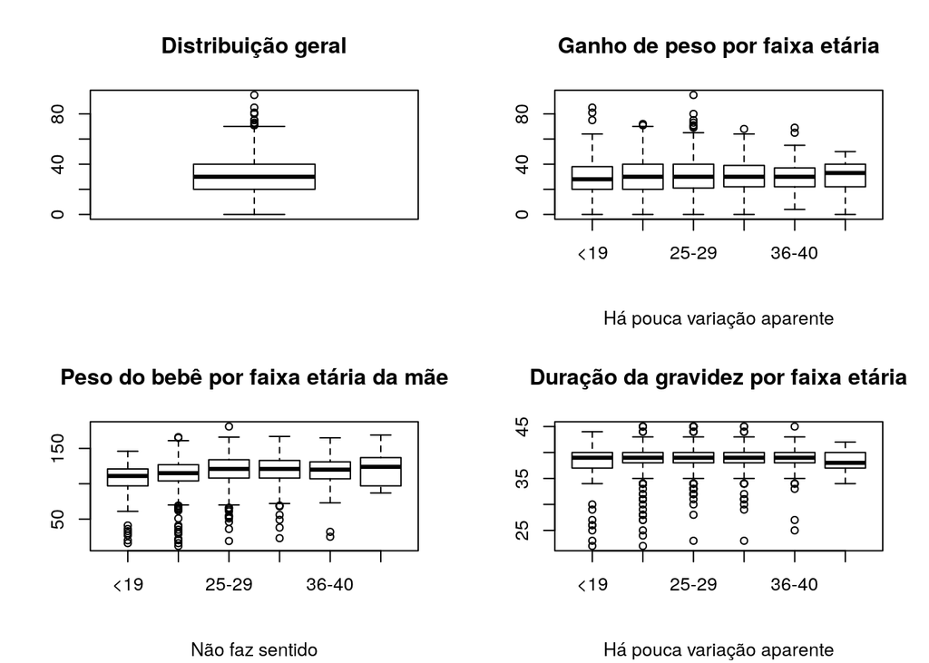

###### Correlações simples

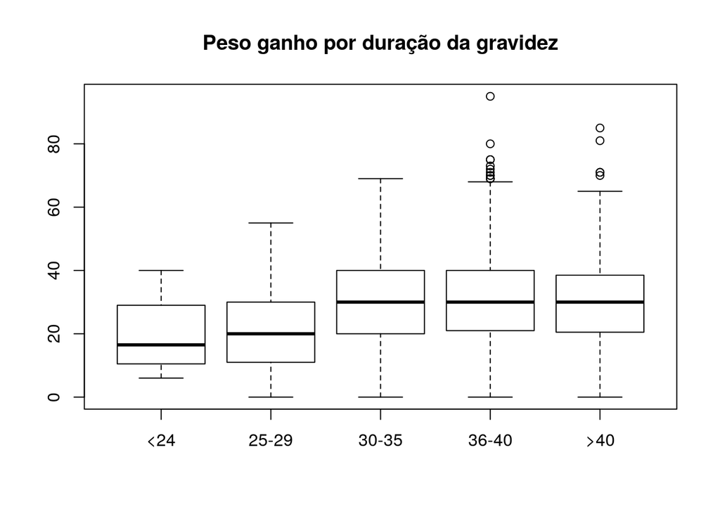

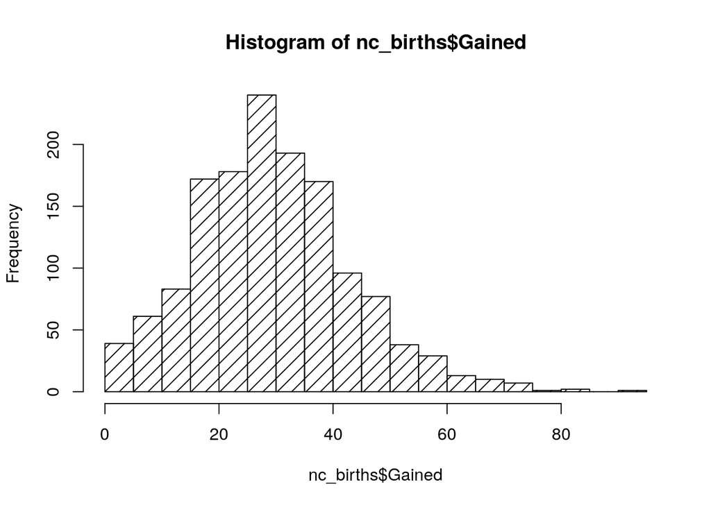

```r
hist(nc_births$Gained, density = 10, breaks = 30)
```

```r
# density(nc_births$Gained)
sw_gained = shapiro.test(nc_births$Gained)

gained_mean = mean(nc_births$Gained, na.rm = T)
```

##### Peso do bebê

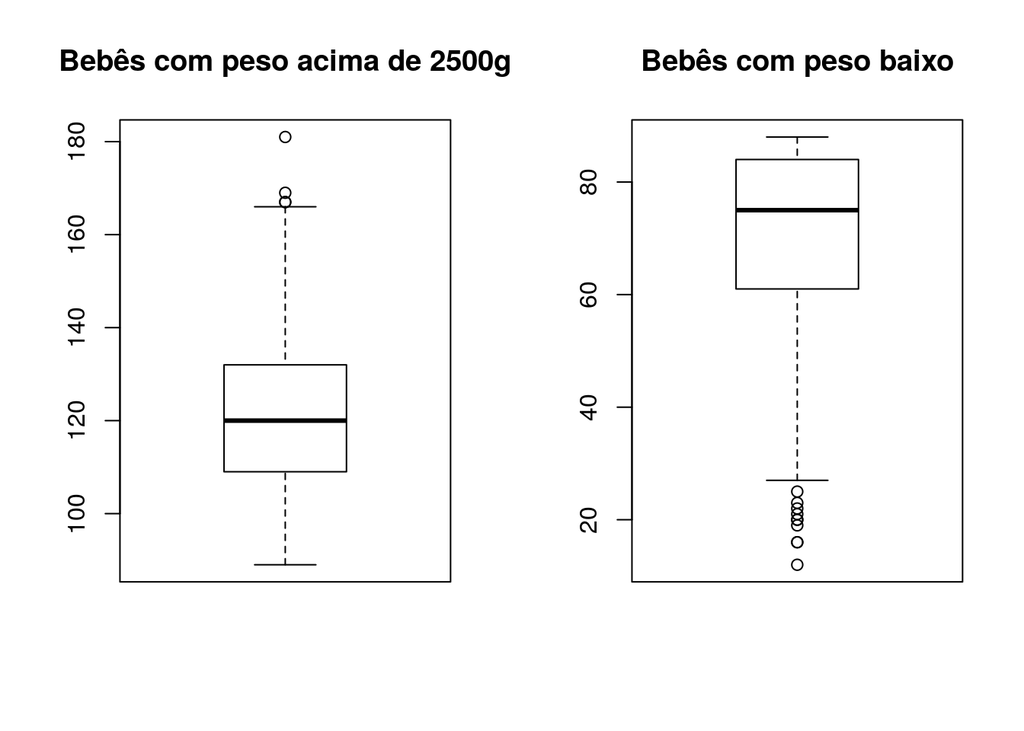

```r
peso_normal = nc_births[nc_births$Low==0,]
baixo_peso = nc_births[nc_births$Low==1,]

par(mfrow = c(1, 2))
boxplot(peso_normal$BirthWeightOz,
        main="Bebês com peso acima de 2500g")

boxplot(baixo_peso$BirthWeightOz,
        main="Bebês com peso baixo")
```

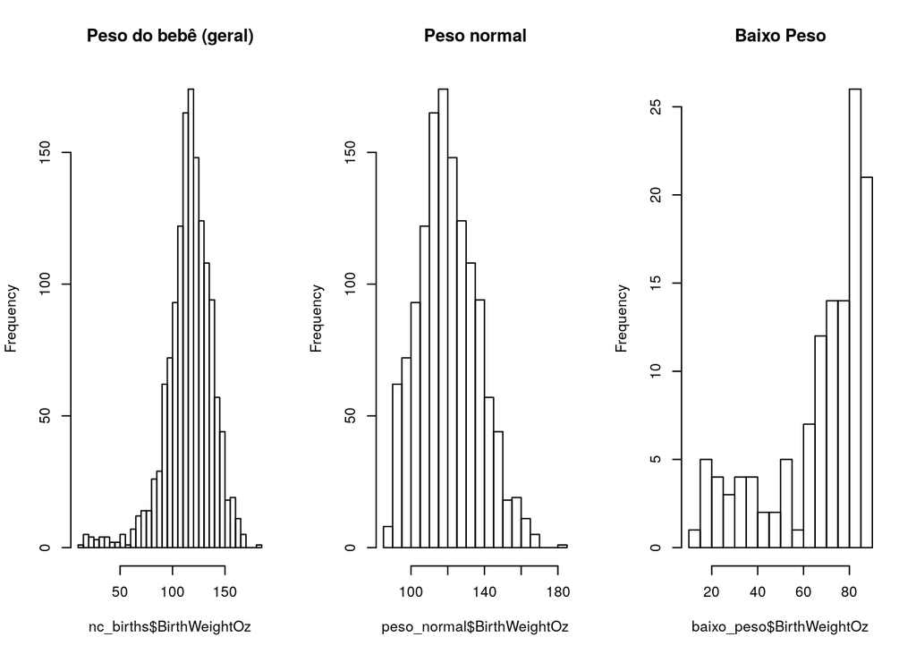

```r
par(mfrow = c(1, 3))
hist(nc_births$BirthWeightOz, breaks=25,
#     xlab="Semanas de gestação",
     main="Peso do bebê (geral)")
hist(peso_normal$BirthWeightOz, breaks=25,
     main="Peso normal")
hist(baixo_peso$BirthWeightOz, breaks=25,
     main="Baixo Peso")
```

##### Duração da gravidez

###### Distribuição de frequências

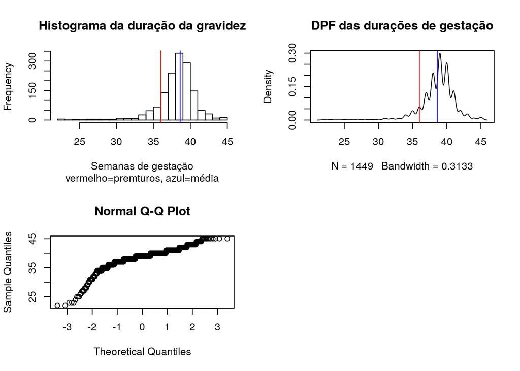

A distribuiçã das frequências de duração da gravidez é enviesada em direção à duração esperada da gestação a termo: 40 semanas após a última menstruação, 38 após a fertilização, e não pode ser considerada uma distribuição Normal (Teste Shapiro-Wilk: W=0.8506, $p=6.3253773\times 10^{-35}$).

A média é 38.621 e o desvio padrão é de 2.699.

### Verificação das observações

#### Peso do bebê: a conversão está correta?

O peso do bebÊ é dado tanto em onças (Oz) quanto em gramas (g). Se não houver erros de conversão de unidade de massa, basta eliminar uma delas, pois têm rigorosamente a mesma informação.

Uma eventual divergência, no entanto, pode indicar erros graves na coleta e/ou registro dos dados, e uma escolha mais complexa precisa ser feita.

```r
# bloco de código - item b

summary(nc_births$BirthWeightGm/nc_births$BirthWeightOz)
```

```
##    Min. 1st Qu.  Median    Mean 3rd Qu.    Max.
##   28.35   28.35   28.35   28.35   28.35   28.35
```

```r
if (mean(nc_births$BirthWeightGm/nc_births$BirthWeightOz)/max(nc_births$BirthWeightGm/nc_births$BirthWeightOz) != 1 ) {
  error("Há um erro de conversão entre Oz e g")
} else {
  if (max(nc_births$BirthWeightGm/nc_births$BirthWeightOz) == 28.35)  {
    print("Todas as conversões de unidade estão corretas")
  } else {
    print("Embora consistentes, as conversões não estão corretas")
  }
}
```

```
## [1] "Todas as conversões de unidade estão corretas"
```

Conclui-se que as colunas `BirthWeightGm` e `BirthWeightOz` contêm informação idêntica, e uma delas pode ser ignorada com segurança.

#### Erros aparentes

Parece haver uma confusão no registro de raças. Há três campos para isso, e encontrei pelo menos uma inconsistência no aparente registro de mães hispânicas como japonesas:

```r
for (race in unique(nc_births$MomRace)) { print(paste(race, nrow(nc_births[nc_births$MomRace == race,])))}  # TODO Um Summary não seria melhor?
```

```
## [1] "white 906"
## [1] "hispanic 164"
## [1] "black 332"
## [1] "other 48"
```

```r
summary(nc_births[nc_births$MomRace=="hispanic", c("RaceMom", "HispMom")])  # Mostra que `RaceMom` é 5 para todas com `MomRace == hispanic`
```

```
##     RaceMom  HispMom
##  Min.   :5   C:  2
##  1st Qu.:5   M:128
##  Median :5   N:  0
##  Mean   :5   O:  3
##  3rd Qu.:5   P:  8
##  Max.   :5   S: 23
```

```r
JapasSoQueNao = nrow(nc_births[nc_births$RaceMom==5,])  # "Japanese", só que não
print(paste("Registros marcados como mães japonesas: ", JapasSoQueNao))
```

```
## [1] "Registros marcados como mães japonesas:  164"
```

```r
print("Mães com RaceMom == 5")
```

```
## [1] "Mães com RaceMom == 5"
```

```r
summary(nc_births[nc_births$RaceMom==5, c("MomRace", "HispMom")])
```

```
##      MomRace    HispMom
##  black   :  0   C:  2
##  hispanic:164   M:128
##  other   :  0   N:  0
##  white   :  0   O:  3
##                 P:  8
##                 S: 23
```

Aparentemente, os 164 registros de mães “japonesas” na verdade são hispânicas com a marca incorreta no campo `RaceMom` mas correto em `MomRace`. O que me leva a crer que o correto seria considerar todas como hispânicas é a variedade do campo `HispMom`, que tem apenas 3 marcadas como “Other hispanic” (e que ainda não sei se há alguma chance de serem japonesas), e a ausência de uma marca “Not hispanic”.

O campo `Low`, segundo a descrição, chama a atenção para bebês cujo peso ao nascer é inferior a 2500g.

```r
# summary(nc_births[nc_births$Low == "Y", c("BirthWeightOz", "BirthWeightGm")])
# summary(nc_births[nc_births$Low == "N", c("BirthWeightOz", "BirthWeightGm")])

# summary(nc_births[nc_births$BirthWeightGm > 2500, c("Low", "BirthWeightOz", "BirthWeightGm")])
nrow(nc_births[nc_births$BirthWeightGm > 2500 & nc_births$Low=='Y', c("Low", "BirthWeightOz", "BirthWeightGm")])  # Deve ser zero
```

```
## [1] 0
```

```r
nrow(nc_births[nc_births$BirthWeightGm <= 2500 & nc_births$Low=='N', c("Low", "BirthWeightOz", "BirthWeightGm")])  # Deve ser zero
```

```
## [1] 0
```

#### Valores ausentes

Por inspeção visual, foi possível detectar valores ausentes nas colunas `Weeks`(1), `Smoke`(5) e `Gained`(40). Faremos avaliação de cada caso assim que der.

TODO: Avaliar casos ausentes

```r
col.sums = colSums(is.na(nc_births))
col.sums[col.sums>0]  # Verificação programática de quais colunas têm NAs
```

```
##  Weeks Gained  Smoke
##      1     40      5
```

```r
nc_births<- cbind(nc_births, somaNulos = rowSums(is.na(nc_births)))
NCB_NAs = nc_births[nc_births$somaNulos > 0,]
NCBnoNAs = nc_births[complete.cases(nc_births),]
```

Parece preocupante a grande quantidade de ausências em `Gained`, que corresponde a 2.7586207% das linhas. A estratégia ideal depende da alavancagem desses registros.

#### Fatores

Segundo a documentação do DataSet, várias dessas colunas podem ser convertidas em fatores:

```r
# Fatorizar o que der
source("factorize.R")

nc_births = NCB_noId(nc_births)
nc_births = NCB_factorize(nc_births)

ncb_births_noGainedNA = nc_births[!is.na(nc_births$Gained), ]
ncb_births_noGainedNA = ncb_births_noGainedNA[ncb_births_noGainedNA$somaNulos == 0, ]

# Remover coluna desnecessária
ncb_births_noGainedNA$somaNulos <- NULL
nc_births$somaNulos <- NULL
```

```r
# boxplot(nc_births$Gained ~ nc_births$MomRace + nc_births$RaceMom, main='Peso ganho por "Raça"') # Pouco útil sem fatores
```

## Análises marginais e multivariadas

2. Faça análises marginais e multivariadas.

### Peso da mãe

Tentativa de explicar o peso ganho em função das outras variáveis.

#### Modelo 1: Naïve

```r
# summary(lm(Gained ~ ., data=nc_births))  # Ficou igual porque lm() eliminou as linhas sem valores para Gained
fit_gained1 = lm(Gained ~ ., data=ncb_births_noGainedNA)
summary(fit_gained1)
```

```
##
## Call:
## lm(formula = Gained ~ ., data = ncb_births_noGainedNA)
##
## Residuals:
##     Min      1Q  Median      3Q     Max
## -38.654  -8.575  -0.865   7.673  61.070
##
## Coefficients: (4 not defined because of singularities)
##                            Estimate Std. Error t value Pr(>|t|)
## (Intercept)                 2.49134   14.67258   0.170 0.865196
## PluralTwins                12.58938    2.27038   5.545 3.51e-08 ***
## PluralTriplets             23.98724    6.80720   3.524 0.000439 ***
## SexF                        0.21416    0.71605   0.299 0.764919
## MomAge                     -0.14622    0.06712  -2.178 0.029546 *
## Weeks                      -0.09129    0.20957  -0.436 0.663171
## MaritalNot Married          0.78212    0.92529   0.845 0.398108
## RaceMomBlack               -2.29084    0.96623  -2.371 0.017881 *
## RaceMomAmericanIndian       3.26467    2.92077   1.118 0.263870
## RaceMomChinese             13.27969    9.42087   1.410 0.158881
## RaceMomHispanic             3.78241    8.20517   0.461 0.644886
## RaceMomFilipino             7.45961   13.34025   0.559 0.576129
## RaceMomOtherAsianOrPacific  1.33596    2.88266   0.463 0.643116
## HispMomM                    3.74721    9.48519   0.395 0.692860
## HispMomN                   14.41303   12.46349   1.156 0.247708
## HispMomO                    6.00810   12.14619   0.495 0.620926
## HispMomP                   11.25094   10.58501   1.063 0.288007
## HispMomS                   14.23326    9.81132   1.451 0.147090
## SmokeY                      0.81559    1.06043   0.769 0.441958
## BirthWeightOz               0.18024    0.02407   7.488 1.24e-13 ***
## BirthWeightGm                    NA         NA      NA       NA
## LowY                       -0.67642    1.81696  -0.372 0.709740
## PremieY                     1.80400    1.55478   1.160 0.246128
## MomRacehispanic                  NA         NA      NA       NA
## MomRaceother                     NA         NA      NA       NA
## MomRacewhite                     NA         NA      NA       NA
## ---
## Signif. codes:  0 '***' 0.001 '**' 0.01 '*' 0.05 '.' 0.1 ' ' 1
##
## Residual standard error: 13.3 on 1387 degrees of freedom
## Multiple R-squared:  0.09555,    Adjusted R-squared:  0.08186
## F-statistic: 6.978 on 21 and 1387 DF,  p-value: < 2.2e-16
```

Curiosamente, vários campos que eu marquei para exclusão aparecem como NA no sumário, mas não todos: `Low` foi considerado, mas ficou terrivelmente insignificante.

Esse modelo explica apenas 8% do resultado. Será que existem modelos melhores?

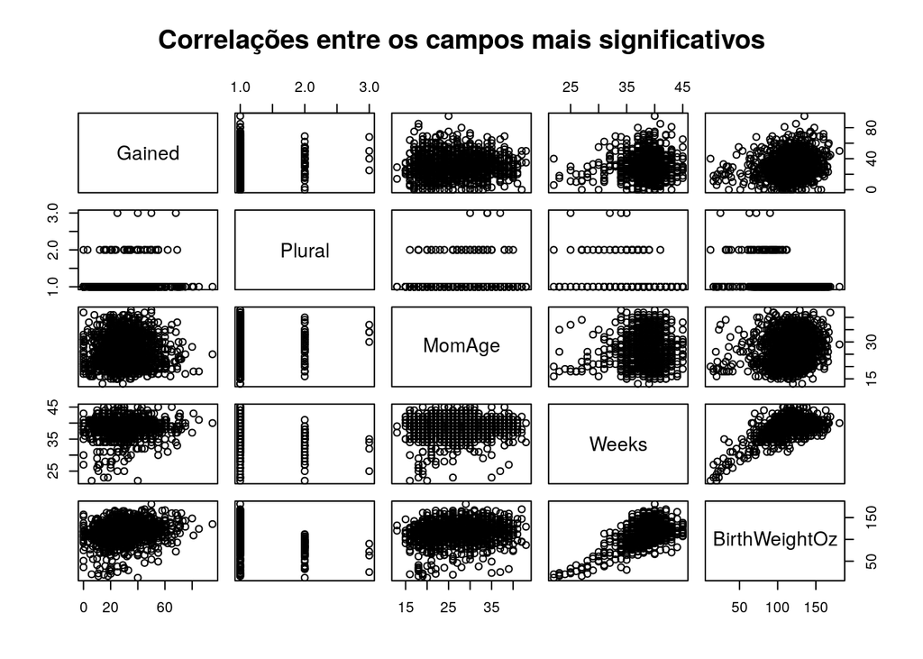

```r
# pairs(Gained ~ ., data=nc_births)
pairs(Gained ~ Plural + MomAge + Weeks + BirthWeightOz,
      data=nc_births,
      main = "Correlações entre os campos mais significativos"
      )
```

```r
# fit_gained1_noNAs = lm(Gained ~ ., data=nc_births, na.action = na.omit)
# summary(fit_gained1_noNAs)

# NCBnoNAs = nc_births[]
```

Não parece haver correlação nenhuma entre esses campos! O único padrão relevante é a já conhecida relação entre a idade gestacional do nascituro e o peso ao nascer: quanto mais próximo do termo (40 semanas), mais pesado; depois do termo, nem tanto.

#### Modelo 2: Menos é mais

```r
fit_gained2 = lm(Gained ~ Plural + BirthWeightOz, data = ncb_births_noGainedNA)
summary(fit_gained2)
```

```
##
## Call:
## lm(formula = Gained ~ Plural + BirthWeightOz, data = ncb_births_noGainedNA)
##
## Residuals:
##     Min      1Q  Median      3Q     Max
## -36.559  -8.976  -0.862   7.714  61.922
##
## Coefficients:
##                Estimate Std. Error t value Pr(>|t|)
## (Intercept)    11.71609    2.06272   5.680 1.64e-08 ***
## PluralTwins    12.46352    2.19662   5.674 1.69e-08 ***
## PluralTriplets 24.14434    6.79263   3.554 0.000391 ***
## BirthWeightOz   0.15823    0.01723   9.184  < 2e-16 ***
## ---
## Signif. codes:  0 '***' 0.001 '**' 0.01 '*' 0.05 '.' 0.1 ' ' 1
##
## Residual standard error: 13.43 on 1405 degrees of freedom
## Multiple R-squared:  0.06504,    Adjusted R-squared:  0.06304
## F-statistic: 32.58 on 3 and 1405 DF,  p-value: < 2.2e-16
```

```r
anova(fit_gained1, fit_gained2)
```

```
## Analysis of Variance Table
##
## Model 1: Gained ~ Plural + Sex + MomAge + Weeks + Marital + RaceMom +
##     HispMom + Smoke + BirthWeightOz + BirthWeightGm + Low + Premie +
##     MomRace
## Model 2: Gained ~ Plural + BirthWeightOz
##   Res.Df    RSS  Df Sum of Sq      F  Pr(>F)
## 1   1387 245181
## 2   1405 253451 -18   -8270.6 2.5993 0.00027 ***
## ---
## Signif. codes:  0 '***' 0.001 '**' 0.01 '*' 0.05 '.' 0.1 ' ' 1
```

Concluo que não vale a pena tentar prever o peso ganho durante a gestação com base nssses dados.

### Peso do bebê

TODO: Modelo 3:

### Tempo de gestação

TODO: Modelos

## Verificação de premissas do modelo linear

c. Verifique as premissas do modelo linear.

- Resíduos
- Independência: os erros são independentes entre si
- Normalidade:
- Homocedasticidade (variância constante)
- Linearidade

### Modelo 1: Naïve

```
## [1] "Propriedades do modelo 1 OK"
```

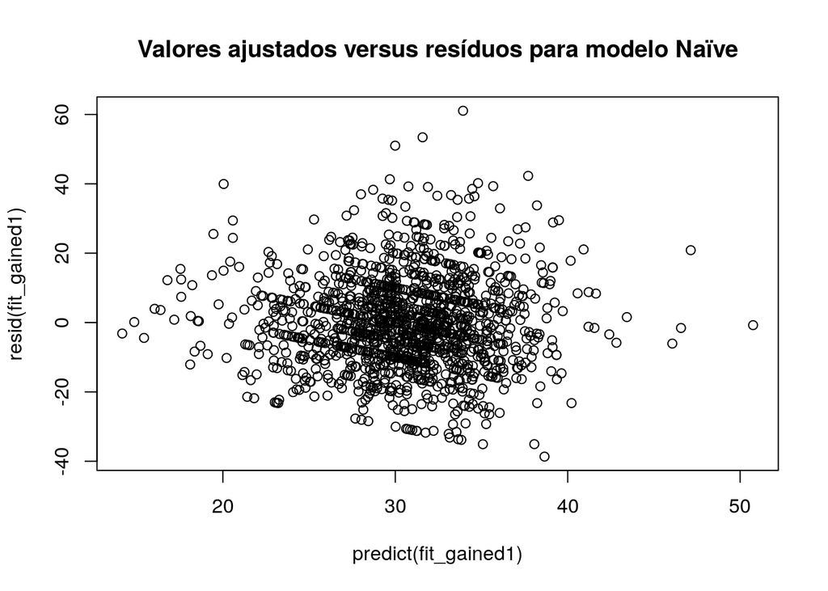

```r
# bloco de código - item c
plot(predict(fit_gained1), resid(fit_gained1),   # data=nc_births,
     main="Valores ajustados versus resíduos para modelo Naïve")
```

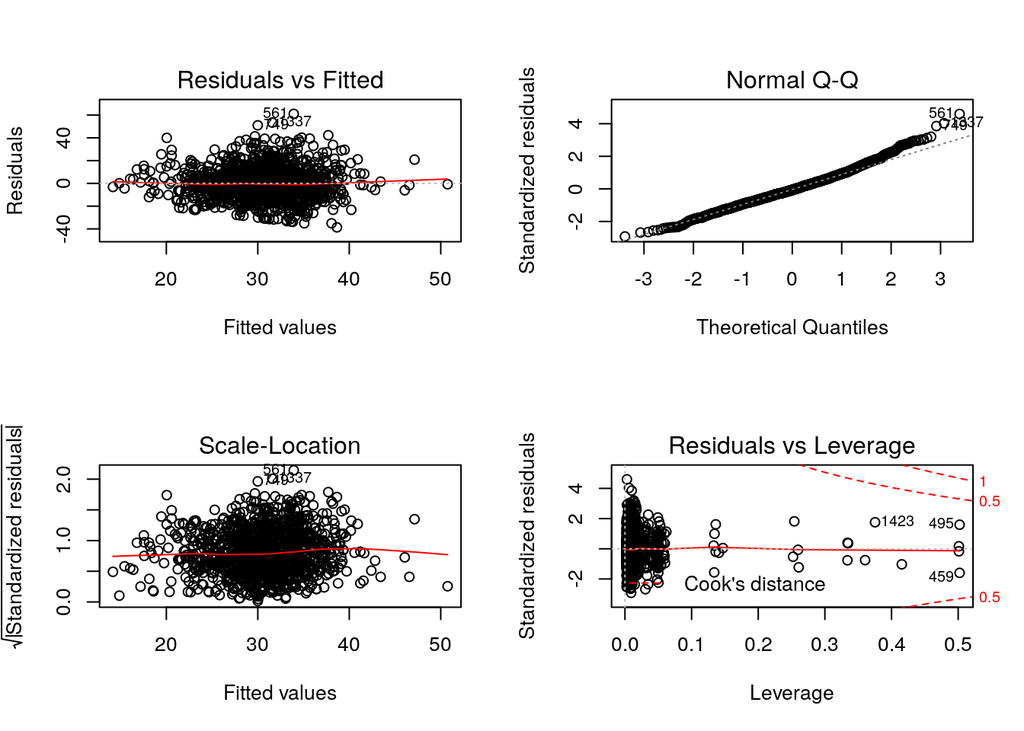

```r
par(mfrow=c(2,2))
plot(fit_gained1)
```

```r
par(mfrow=c(1,1))
```

### Modelo 2: Menos é mais

```r
pro_res_2 = verifica_props_residuos(
  fit_gained2$residuals,
  ncb_births_noGainedNA$Gained,
  fit_gained2$fitted.values
  )

if (pro_res_2$is.small) {
    print("Propriedades do modelo 2 OK")
  } else {
  print("Alguma propriedade do modelo 2 não tem o valor esperado:")
  print_props_residuos(pro_res_2)
}
```

```
## [1] "Propriedades do modelo 2 OK"
```

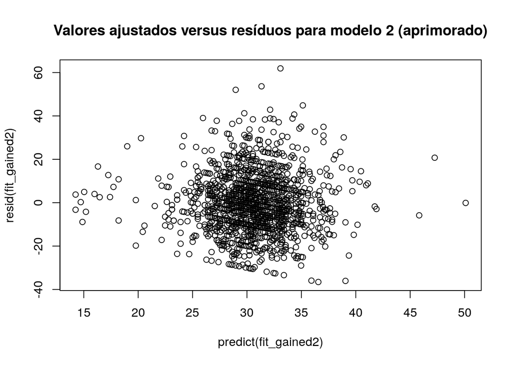

```r
plot(predict(fit_gained2), resid(fit_gained2),   # data=nc_births,
     main="Valores ajustados versus resíduos para modelo 2 (aprimorado)")
```

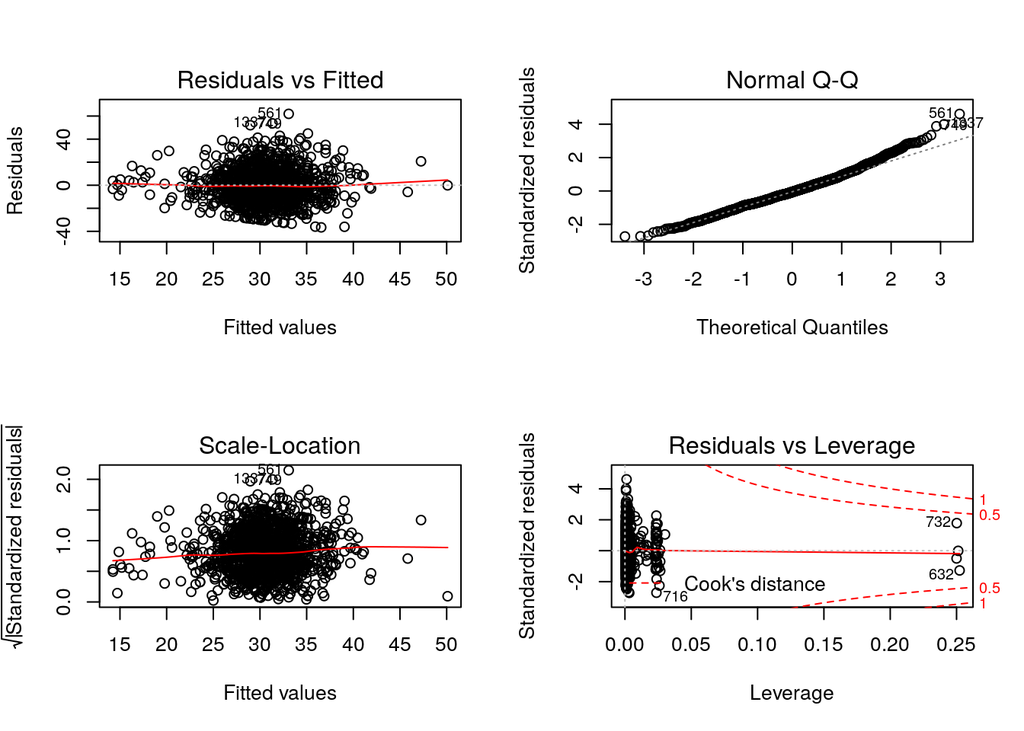

```r
par(mfrow=c(2,2))
plot(fit_gained2)
```

```r
par(mfrow=c(1,1))
```

TODO: Interpretação (nada se destaca aí)

### Modelo 3: Peso do bebê

### Modelo X: Duração da gravidez

## Propostas

d. Proposta de modelo

Com base nas análises, proponha um ou mais modelos lineares multivariados. Explique a sua escolha.

```r
# bloco de código - item d
```

### Predições

5. Utilize o(s) modelo(s) proposto(s) para fazer pelo menos uma predição.

```r
# bloco de código - item e
```

# Conclusões e comentários

## Comentários

Em retrospecto, penso que teria perdido menos tempo se tivesse feito uma simples análise do R² ajustado de todas as variáveis numéricas (já que são poucas). Minha primeira escolha foi justamente a que tem menor potencial de explicação, com os dados disponíveis.

Esses valores sugerem um limite superior para o poder de explicação de um modelo linear que explique as obervações de cara uma dessas variáveis.

Os dados da tabela abaixo foram obtidos da execução do script varios_modelos.R, ideia que só tive perto do final do prazo para entregar o exercício.

R² ajustado de modelos naïve para variáveis quantitativas

| Coluna | R² ajustado |
| --- | --- |
| MomAge | 0.239690016396153 |
| Weeks | 0.588115108607321 |
| Gained | 0.0818566109518561 |
| BirthWeightOz | 0.568165398604105 |

## Suspeitas

Até agora, parece não haver evidências suficientes para compor um modelo linear do peso ganho em função de algumas das outras variáveis. O máximo possível de explicação é de 8% com todos os campos, e vários deles geram coeficientes sem significância estatística ($p>5\%$).

Quando passei a considerar o peso do bebê ao nascer (BirthWeightOz) como variável dependente, obtive modelos com maior poder de predição ($ {R_{ajust}}^2 > 40%$)

## ENTREGA EM 31/10/2018, ÀS 23h59.